# Met_Master Merge with Eddy_Pro_Master: Data from 2019-11-18

```r
library(tidyverse)
source("calc_footprint_FFP.R")
library(ggplot2)
library(modelr)
options(na.action = na.warn)
```

# Lists

```r
rm(list=ls())
```

# Defining the data I/O directory for the Eddy Master File

```r
path_eddy<-"C:\\Users\\Tommy\\flux\\Data-exploring\\02_Concord\\"
path.in_eddy<-paste(path_eddy,"01_Proccessed_Data",sep="")
path.out_eddy<-paste(path_eddy,"03_combined_data",sep="")
ver<-"Master_Eddy"
file.name_eddy<-paste("master_eddy_pro_concord",sep="")
```

# read in eddypro full output Master file, parse variable names

```r
data_master_eddy<-read.csv(paste(path.in_eddy,"\\",ver,"\\",file.name_eddy,".csv",sep=""),
                  header=F,
                  skip=3,
                  na.strings=c(-9999),
                  stringsAsFactors = F)
colnames(data_master_eddy)<-colnames(
  read.csv(paste(path.in_eddy,"\\",ver,"\\",file.name_eddy,".csv",sep=""),
           header=T,
           skip=1))
```

# Defining the data I/O directory for the Master met_data

```r
path_met<-"C:\\Users\\Tommy\\flux\\Data-exploring\\02_Concord\\"
path.in_met<-paste(path_met,"01_Proccessed_Data",sep="")
path.out_met<-paste(path_met,"03_combined_data",sep="")
ver<-"met_data"
file.name<-paste("MET_data_master",sep="")
```

#read in Met_Data Master file, parse variable names and define N/As#

```r
met_data_master<-read.csv(paste(path.in_met,"\\",ver,"\\",file.name,".csv",sep=""),
                  header=F,
                  skip=4,
                  na.strings=c("NAN"),
                  stringsAsFactors = F)
colnames(met_data_master)<-colnames(
  read.csv(paste(path.in_met,"\\",ver,"\\",file.name,".csv",sep=""),
           header=T,
           skip= 1))
```

# Parsing the time stamp converting it into a POSIXlt vector

**interpreting date and time into new timestamp column**

**Then taking that time stamp column and turning each time into a unique number (time.id) so I can join based on that. As it can be really tricky to join/merge based on time stamps alone**

**Or I could make sure both time stamps are characters and match them that way**

**Finally ploting time.id to make sure my times translate linearily**

```r
data_master_eddy$TIMESTAMP<-strptime(paste(data_master_eddy$date,data_master_eddy$time,sep=" "),format="%m/%d/%Y %H:%M", tz = "GMT")

data_master_eddy$time.id<-data_master_eddy$TIMESTAMP$year+1900+(data_master_eddy$TIMESTAMP$yday)/366+(data_master_eddy$TIMESTAMP$hour)/366/24+ (data_master_eddy$TIMESTAMP$min)/366/24/60

data_master_eddy$time.id[1:50]
```

```
 [1] 2019.450 2019.450 2019.450 2019.450 2019.450 2019.450 2019.450 2019.450 2019.451
[10] 2019.451 2019.451 2019.451 2019.451 2019.451 2019.451 2019.451 2019.451 2019.451
[19] 2019.451 2019.451 2019.451 2019.451 2019.451 2019.451 2019.451 2019.452 2019.452
[28] 2019.452 2019.452 2019.452 2019.452 2019.452 2019.452 2019.452 2019.452 2019.452
[37] 2019.452 2019.452 2019.452 2019.452 2019.452 2019.452 2019.452 2019.453 2019.453
[46] 2019.453 2019.453 2019.453 2019.453 2019.453
```

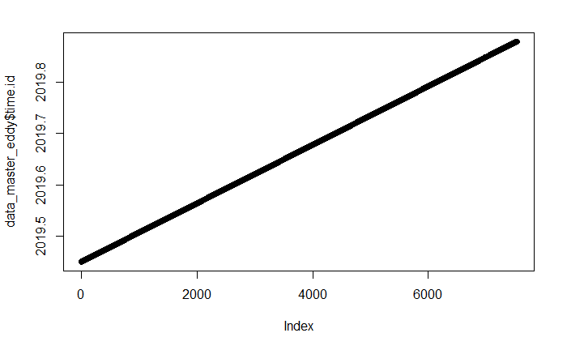

```r
plot(data_master_eddy$time.id)
```

```r
which(duplicated(data_master_eddy$time.id))
```

```
integer(0)
```

#Taking the met_data and turning the time stamp into posixt format#

```r
met_data_master$TIMESTAMP<-strptime(met_data_master$TIMESTAMP,
                           format ="%m/%d/%Y %H:%M", tz = "GMT")

met_data_master$TIMESTAMP[1:20]
```

```
 [1] "2019-06-25 09:00:00 GMT" "2019-06-25 09:30:00 GMT" "2019-06-25 10:00:00 GMT"
 [4] "2019-06-25 10:30:00 GMT" "2019-06-25 11:00:00 GMT" "2019-06-25 11:30:00 GMT"
 [7] "2019-06-25 12:00:00 GMT" "2019-06-25 12:30:00 GMT" "2019-06-25 13:00:00 GMT"
[10] "2019-06-25 13:30:00 GMT" "2019-06-25 14:00:00 GMT" "2019-06-25 14:30:00 GMT"
[13] "2019-06-25 15:00:00 GMT" "2019-06-25 15:30:00 GMT" "2019-06-25 16:00:00 GMT"
[16] "2019-06-25 16:30:00 GMT" "2019-06-25 17:00:00 GMT" "2019-06-25 17:30:00 GMT"
[19] "2019-06-25 18:00:00 GMT" "2019-06-25 18:30:00 GMT"
```

#Making sure timestamp columns line up#

```r
met_data_master$TIMESTAMP[1:10]
```

```
 [1] "2019-06-25 09:00:00 GMT" "2019-06-25 09:30:00 GMT" "2019-06-25 10:00:00 GMT"
 [4] "2019-06-25 10:30:00 GMT" "2019-06-25 11:00:00 GMT" "2019-06-25 11:30:00 GMT"
 [7] "2019-06-25 12:00:00 GMT" "2019-06-25 12:30:00 GMT" "2019-06-25 13:00:00 GMT"
[10] "2019-06-25 13:30:00 GMT"
```

```r
data_master_eddy$TIMESTAMP[1:10]
```

```
 [1] "2019-06-14 17:30:00 GMT" "2019-06-14 18:00:00 GMT" "2019-06-14 18:30:00 GMT"
 [4] "2019-06-14 19:00:00 GMT" "2019-06-14 19:30:00 GMT" "2019-06-14 20:00:00 GMT"
 [7] "2019-06-14 20:30:00 GMT" "2019-06-14 21:00:00 GMT" "2019-06-14 21:30:00 GMT"
[10] "2019-06-14 22:00:00 GMT"
```

#creating a time id for the MET Data so I I can join the MET and Eddy Pro Data#

```r
met_data_master$time.id <-met_data_master$TIMESTAMP$year+1900+(met_data_master$TIMESTAMP$yday)/366+(met_data_master$TIMESTAMP$hour)/366/24 + (met_data_master$TIMESTAMP$min)/366/24/60

met_data_master$time.id[1:20]
```

```
 [1] 2019.479 2019.479 2019.479 2019.479 2019.479 2019.479 2019.480 2019.480 2019.480
[10] 2019.480 2019.480 2019.480 2019.480 2019.480 2019.480 2019.480 2019.480 2019.480
[19] 2019.480 2019.480
```

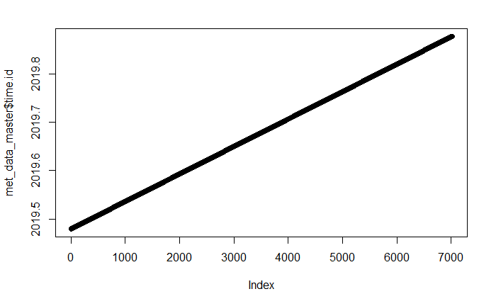

```r
plot(met_data_master$time.id)
```

```r
which(duplicated(met_data_master$time.id))
```

```
integer(0)
```

```r
met_data_master
```

| TIMESTAMP | RECORD | BattV_Avg | PTemp_C_Avg | AM25T_ref_Avg | TC_Avg.1. | TC_Avg.2. | TC_Avg.3. | TC_Avg.4. | TC_Avg.5. | TC_Avg.6. | TC_Avg.7. | TC_Avg.8. | TC_Avg.9. | TC_Avg.10. | TC_Avg.11. | TC_Avg.12. | TC_Avg.13. | TC_Avg.14. | TC_Avg.15. | TC_Avg.16. | TC_Avg.17. | TC_Avg.18. | TC_Avg.19. | TC_Avg.20. | TC_Avg.21. | TC_Avg.22. | TC_Avg.23. | TC_Avg.24. | TC_Avg.25. | … |
| --- | --- | --- | --- | --- | --- | --- | --- | --- | --- | --- | --- | --- | --- | --- | --- | --- | --- | --- | --- | --- | --- | --- | --- | --- | --- | --- | --- | --- | --- | --- |
|  | 530 | 19.35 | 24.83 | NA | NA | NA | NA | NA | NA | NA | NA | NA | NA | NA | NA | NA | NA | NA | NA | NA | NA | NA | NA | NA | NA | NA | NA | NA | NA | … |
|  | 531 | 19.35 | 26.16 | NA | NA | NA | NA | NA | NA | NA | NA | NA | NA | NA | NA | NA | NA | NA | NA | NA | NA | NA | NA | NA | NA | NA | NA | NA | NA | … |
|  | 532 | 19.35 | 27.16 | NA | NA | NA | NA | NA | NA | NA | NA | NA | NA | NA | NA | NA | NA | NA | NA | NA | NA | NA | NA | NA | NA | NA | NA | NA | NA | … |
|  | 533 | 19.34 | 27.90 | NA | NA | NA | NA | NA | NA | NA | NA | NA | NA | NA | NA | NA | NA | NA | NA | NA | NA | NA | NA | NA | NA | NA | NA | NA | NA | … |
|  | 534 | 19.34 | 28.61 | NA | NA | NA | NA | NA | NA | NA | NA | NA | NA | NA | NA | NA | NA | NA | NA | NA | NA | NA | NA | NA | NA | NA | NA | NA | NA | … |
|  | 535 | 19.34 | 29.30 | NA | NA | NA | NA | NA | NA | NA | NA | NA | NA | NA | NA | NA | NA | NA | NA | NA | NA | NA | NA | NA | NA | NA | NA | NA | NA | … |
|  | 536 | 19.33 | 29.95 | NA | NA | NA | NA | NA | NA | NA | NA | NA | NA | NA | NA | NA | NA | NA | NA | NA | NA | NA | NA | NA | NA | NA | NA | NA | NA | … |
|  | 537 | 19.33 | 30.38 | NA | NA | NA | NA | NA | NA | NA | NA | NA | NA | NA | NA | NA | NA | NA | NA | NA | NA | NA | NA | NA | NA | NA | NA | NA | NA | … |
|  | 538 | 19.34 | 30.86 | NA | NA | NA | NA | NA | NA | NA | NA | NA | NA | NA | NA | NA | NA | NA | NA | NA | NA | NA | NA | NA | NA | NA | NA | NA | NA | … |
|  | 539 | 19.33 | 31.13 | NA | NA | NA | NA | NA | NA | NA | NA | NA | NA | NA | NA | NA | NA | NA | NA | NA | NA | NA | NA | NA | NA | NA | NA | NA | NA | … |

[output cut: 990 more lines]

#Joining the Met_Data and Eddy Pro Data Sets#

**with merge**

```r
combo_master_ed_met<- merge(met_data_master[,-which(colnames(met_data_master)=="TIMESTAMP")], data_master_eddy[,-which(colnames(data_master_eddy)=="TIMESTAMP")], by = "time.id")



colnames(combo_master_ed_met)
```

```
  [1] "time.id"                       "RECORD"
  [3] "BattV_Avg"                     "PTemp_C_Avg"
  [5] "AM25T_ref_Avg"                 "TC_Avg.1."
  [7] "TC_Avg.2."                     "TC_Avg.3."
  [9] "TC_Avg.4."                     "TC_Avg.5."
 [11] "TC_Avg.6."                     "TC_Avg.7."
 [13] "TC_Avg.8."                     "TC_Avg.9."
 [15] "TC_Avg.10."                    "TC_Avg.11."
 [17] "TC_Avg.12."                    "TC_Avg.13."
 [19] "TC_Avg.14."                    "TC_Avg.15."
 [21] "TC_Avg.16."                    "TC_Avg.17."
 [23] "TC_Avg.18."                    "TC_Avg.19."
 [25] "TC_Avg.20."                    "TC_Avg.21."
 [27] "TC_Avg.22."                    "TC_Avg.23."
 [29] "TC_Avg.24."                    "TC_Avg.25."
```

[output cut: 71 more lines]

#Add back time stamp to the combo_master_ed_met#

```r
combo_master_ed_met$TIMESTAMP<-strptime(paste(combo_master_ed_met$date,combo_master_ed_met$time,sep=" "),format="%m/%d/%Y %H:%M", tz = "GMT")

combo_master_ed_met$TIMESTAMP[1:10]
```

```
 [1] "2019-06-25 09:00:00 GMT" "2019-06-25 09:30:00 GMT" "2019-06-25 10:00:00 GMT"
 [4] "2019-06-25 10:30:00 GMT" "2019-06-25 11:00:00 GMT" "2019-06-25 11:30:00 GMT"
 [7] "2019-06-25 12:00:00 GMT" "2019-06-25 12:30:00 GMT" "2019-06-25 13:00:00 GMT"
[10] "2019-06-25 13:30:00 GMT"
```

#Creating a CSV File of my combine Master File!#

```r
write.csv(combo_master_ed_met,
          paste(path.out_eddy,ver,"combo_master_ed_met",sep=""),
          quote = T,
          row.names = F)
```

```r
combo_master_ed_met$LE.[!is.na(combo_master_ed_met$qc_LE)&combo_master_ed_met$qc_LE==2]<-NA

combo_master_ed_met$qqc_h2o_flux[!is.na(combo_master_ed_met$qc_h2o_flux)&combo_master_ed_met$qc_h2o_flux==2]<-NA

combo_master_ed_met$H[!is.na(combo_master_ed_met$qc_H)&combo_master_ed_met$qc_H==2]<-NA

combo_master_ed_met$u.[!is.na(combo_master_ed_met$qc_Tau)&combo_master_ed_met$qc_Tau==2]<-NA

combo_master_ed_met$co2_flux[!is.na(combo_master_ed_met$co2_flux)&combo_master_ed_met$co2_flux==2]<-NA
```

# latent heat, sensible heat, h20_flux, and relative humidity by day for whole period

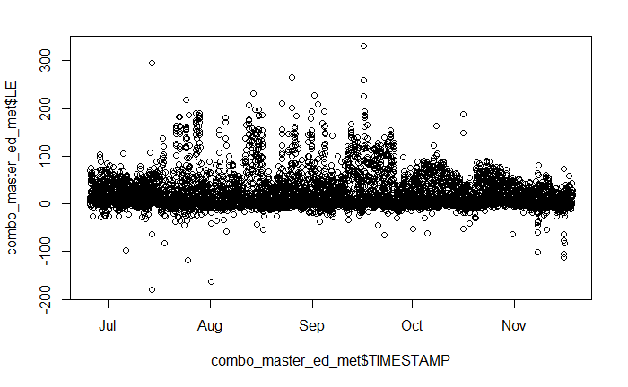

```r
plot(combo_master_ed_met$TIMESTAMP ,combo_master_ed_met$LE)
```

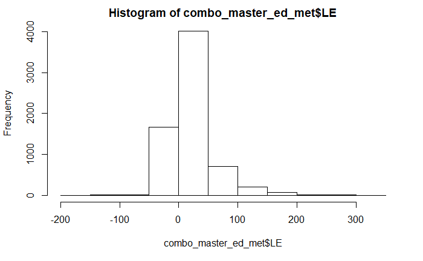

```r
hist(combo_master_ed_met$LE)
```

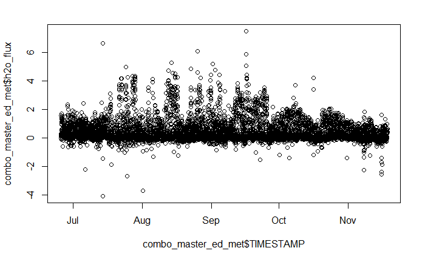

```r
plot(combo_master_ed_met$TIMESTAMP ,combo_master_ed_met$h2o_flux)
```

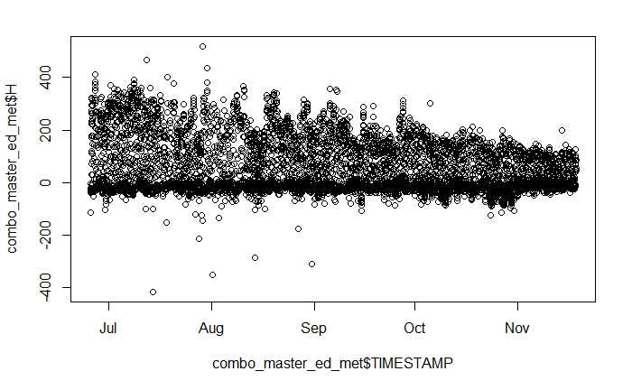

```r
plot(combo_master_ed_met$TIMESTAMP ,combo_master_ed_met$H)
```

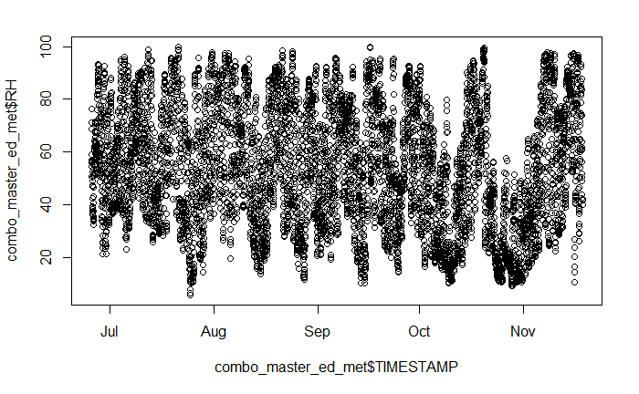

```r
plot(combo_master_ed_met$TIMESTAMP ,combo_master_ed_met$RH)
```

```r
NA
NA
NA
NA
NA
```

#Plotting Co2 flux by timstamp on x-axis.

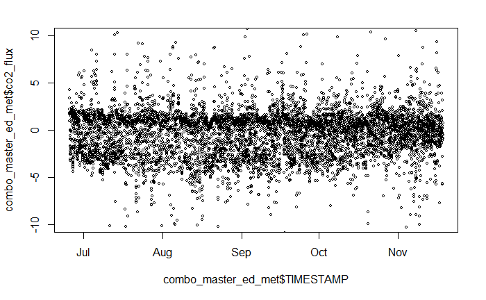

```r
plot(combo_master_ed_met$TIMESTAMP ,combo_master_ed_met$co2_flux, ylim = c(-10,10),cex=0.6)
```

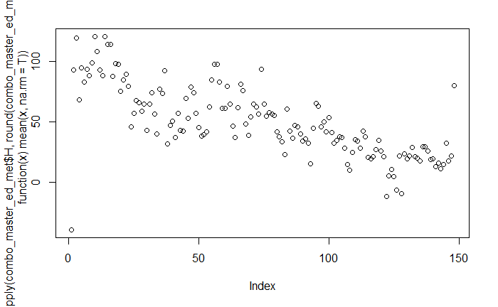

```r
plot(tapply(combo_master_ed_met$H,round(combo_master_ed_met$DOY),function(x) mean(x,na.rm=T)))
```

```r
NA
NA
NA
```

#line plot of c02_fluxes#

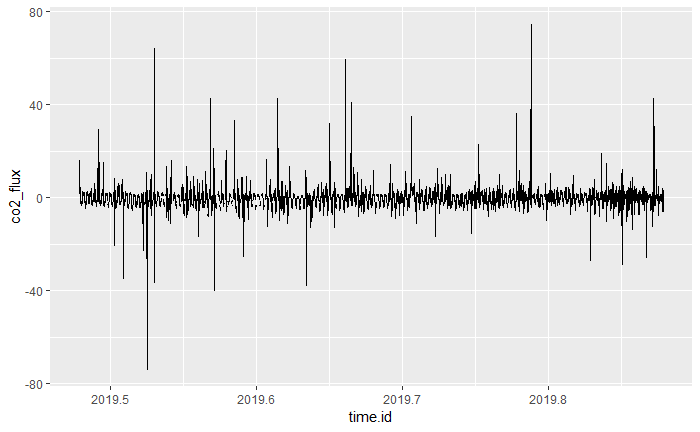

```r
ggplot(data = combo_master_ed_met) +
  geom_line(mapping = aes(x = time.id , y = co2_flux))
```

#latent heat and Sensible heat plotted over eachother

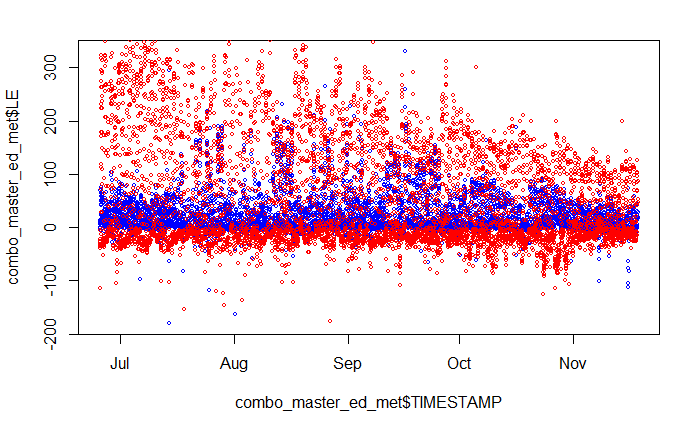

```r
plot(combo_master_ed_met$TIMESTAMP ,combo_master_ed_met$LE,pch=1,col="blue",cex=0.6)
points(combo_master_ed_met$TIMESTAMP ,combo_master_ed_met$H,col="red",pch=1,cex=0.6)
```

#air temperatue by sensible heat an U* by co2 flux

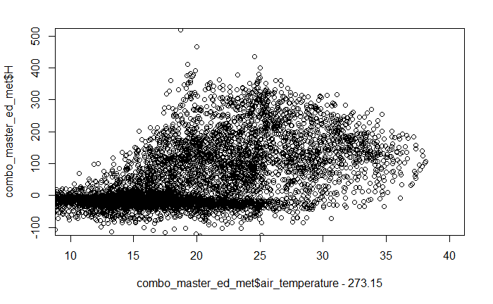

```r
plot(combo_master_ed_met$air_temperature-273.15,combo_master_ed_met$H,xlim=c(10,40),ylim=c(-100,500))
```

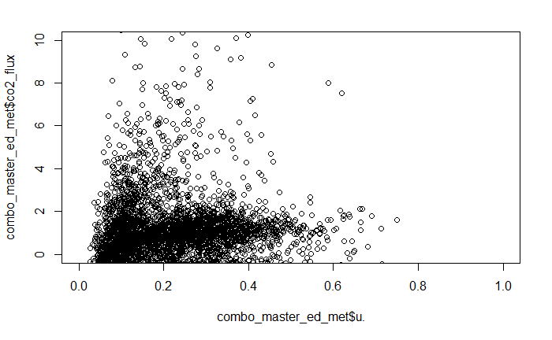

```r
plot(combo_master_ed_met$u. ,combo_master_ed_met$co2_flux, ylim = c(0, 10), xlim = c(0,1))
```

#Adding best fit line to air temperature by sensible heat

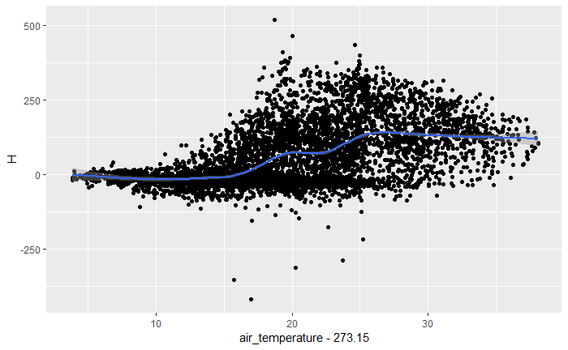

```r
ggplot(data = combo_master_ed_met) +
  geom_point(mapping = aes(x = air_temperature-273.15, y = H)) +
  geom_smooth(mapping = aes(x = air_temperature-273.15, y = H))
```

```r
NA
NA
```

#best fit line to U* bt co2 flux

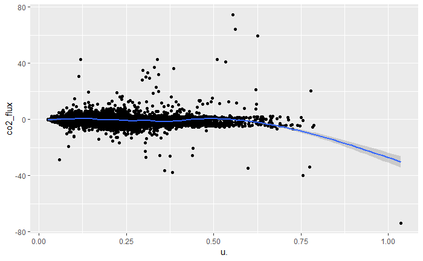

```r
ggplot(data = combo_master_ed_met) +
  geom_point(mapping = aes(x = u., y = co2_flux)) +
  geom_smooth(mapping = aes(x = u., y = co2_flux))
```

```r
NA
NA
```

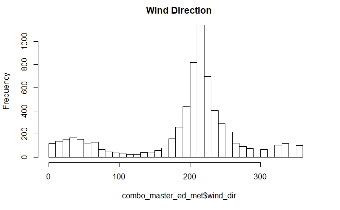

```r
library(tidyverse)
hist(combo_master_ed_met$wind_dir, xlim = c(0,370), breaks = 36, main = "Wind Direction")
```

#Comparing MET Temperature data to temperature reading from Licor intruments#

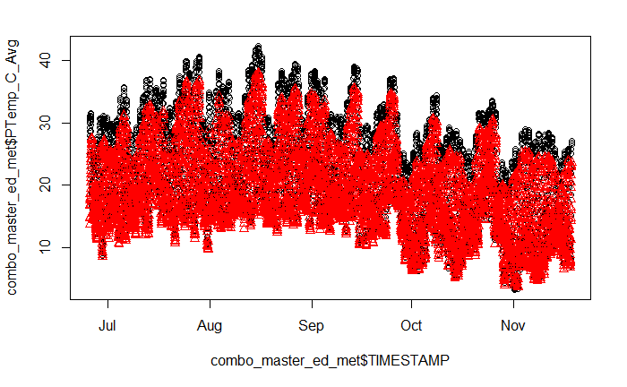

```r
plot(combo_master_ed_met$TIMESTAMP ,combo_master_ed_met$PTemp_C_Avg)
points(combo_master_ed_met$TIMESTAMP,combo_master_ed_met$air_temperature-273.15,col="red",pch=2)
```

#Adding coefficient to Net radiation#

```r
combo_master_ed_met$Correct_NR = (combo_master_ed_met$NR_Wm2_Avg*10)/14.2
```

```r
summary(combo_master_ed_met$Correct_NR[c(1:600,2500:4000)])
```

```
   Min. 1st Qu.  Median    Mean 3rd Qu.    Max.
-106.27  -69.79  -17.23  121.53  339.30  644.37
```

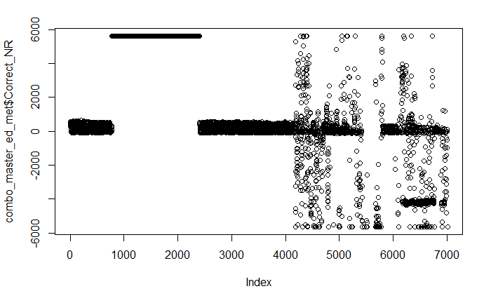

```r
plot(combo_master_ed_met$Correct_NR)
```

filtering out bad NR numbers

```r
combo_master_ed_met$Correct_NR[!is.na(combo_master_ed_met$Correct_NR)&(combo_master_ed_met$Correct_NR<(-150)|combo_master_ed_met$Correct_NR>800)]<-NA
summary(combo_master_ed_met$Correct_NR)
```

```
   Min. 1st Qu.  Median    Mean 3rd Qu.    Max.    NA's
-146.97  -67.96  -49.57   88.05  250.14  775.35    3106
```

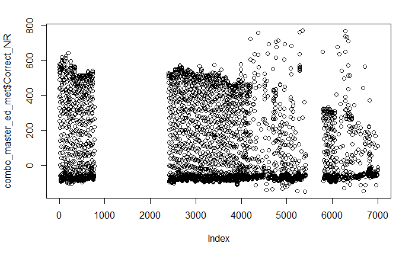

```r
plot(combo_master_ed_met$Correct_NR)
```